# Simple linear regression

```r
library(tidyverse)
library(ggplot2)
```

```r
sample <- tibble(
  height = c(176, 164, 181, 168, 195, 185, 166, 180, 188, 174),
  weight = c(82, 65, 85, 76, 90, 92, 68, 83, 94, 74 )
)
```

$$\widehat{y} = b_0 + b_1 \times x$$
where, by convention

- $\widehat{y}$ is used to indicate a **fitted** $y$-value (outcome)
- we label the **intercept** $b_0$
- we label the **slope** $b_1$. Sometimes we might label the slope as $b_\textrm{<name>}$ where $\textrm{<name>}$ is the explanatory variable, e.g. $b_{\textrm{weight}}$

So in our case, we would fit an equation of the form

$$\widehat{height} = b_0 + b_{\textrm{weight}} \times \textrm{weight}$$

Let’s see some sample data that we might want to fit

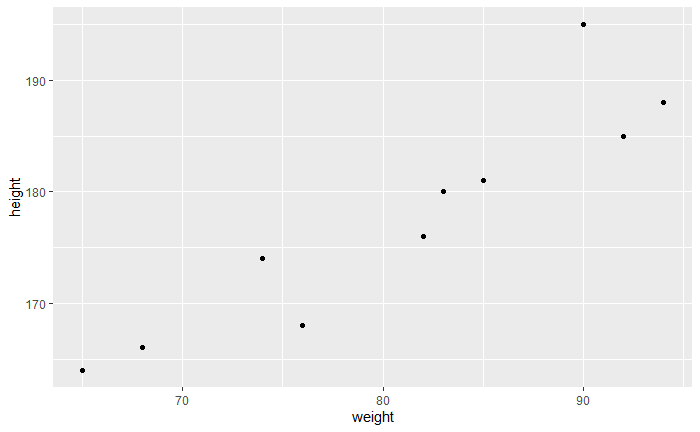

```r
sample %>%
  ggplot(aes(weight, height)) +
  geom_point()
```

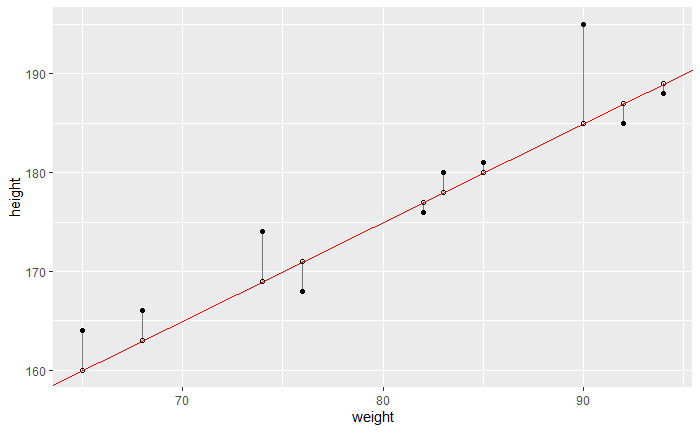

```r
line <- function(x, b0, b1) {
  b0 + x * b1
}

sample <- sample %>%
  mutate(fit_height = line(weight, b0 = 95, b1 = 1))

sample %>%
  ggplot(aes(weight, height)) +
  geom_point() +
  geom_point(aes(y = fit_height), shape = 1) +
  geom_abline(slope = 1, intercept = 95, col = "red") +
  geom_segment(aes(xend = weight, yend = fit_height), alpha = 0.5)
```

We also show the *residuals* as vertical line segments.

A *residual* is the difference between a fitted outcome value and an actual outcome value. These are also sometimes called *errors*, but ‘residuals’ is better, as the term ‘error’ gets used everywhere in statistics!

```r
# see for the point options
?points
```

```r
sample <- sample %>%
  mutate(residuals = height - fit_height)

sample
```

| height | weight | fit_height | residuals |
| --- | --- | --- | --- |
| 176 | 82 | 177 | -1 |
| 164 | 65 | 160 | 4 |
| 181 | 85 | 180 | 1 |
| 168 | 76 | 171 | -3 |
| 195 | 90 | 185 | 10 |
| 185 | 92 | 187 | -2 |
| 166 | 68 | 163 | 3 |
| 180 | 83 | 178 | 2 |
| 188 | 94 | 189 | -1 |
| 174 | 74 | 169 | 5 |

Now, when we **fit** the linear model to the data, we vary $b_0$ and $b_{\textrm{weight}}$ to make the residuals **as small as possible**. Don’t worry too much about how we do this in practice: R essentially does it for us using some fancy matrix algebra! It’s more important to understand the concept than the technical detail.

```r
sample %>%
  summarise(sum_residuals = sum(residuals))
```

| sum_residuals |
| --- |
| 18 |

```r
sample <- sample %>%
  mutate(sq_residual = residuals^2)
sample
```

| height | weight | fit_height | residuals | sq_residual |
| --- | --- | --- | --- | --- |
| 176 | 82 | 177 | -1 | 1 |
| 164 | 65 | 160 | 4 | 16 |
| 181 | 85 | 180 | 1 | 1 |
| 168 | 76 | 171 | -3 | 9 |
| 195 | 90 | 185 | 10 | 100 |
| 185 | 92 | 187 | -2 | 4 |
| 166 | 68 | 163 | 3 | 9 |
| 180 | 83 | 178 | 2 | 4 |
| 188 | 94 | 189 | -1 | 1 |
| 174 | 74 | 169 | 5 | 25 |

```r
sample %>%
  summarise(sum_sq_residual = sum(sq_residual))
```

| sum_sq_residual |
| --- |
| 170 |

```r
?lm
```

```r
class(sample$weight)
```

```
[1] "numeric"
```

```r
class(~ weight)
```

```
[1] "formula"
```

```r
sample
```

| height | weight | fit_height | residuals | sq_residual |
| --- | --- | --- | --- | --- |
| 176 | 82 | 177 | -1 | 1 |
| 164 | 65 | 160 | 4 | 16 |
| 181 | 85 | 180 | 1 | 1 |
| 168 | 76 | 171 | -3 | 9 |
| 195 | 90 | 185 | 10 | 100 |
| 185 | 92 | 187 | -2 | 4 |
| 166 | 68 | 163 | 3 | 9 |
| 180 | 83 | 178 | 2 | 4 |
| 188 | 94 | 189 | -1 | 1 |
| 174 | 74 | 169 | 5 | 25 |

```r
new_model <- lm(height ~ weight, sample)
new_model
```

```
Call:
lm(formula = height ~ weight, data = sample)

Coefficients:
(Intercept)       weight
   102.1758       0.9336
```

```r
fitted(new_model)
```

```
       1        2        3        4        5        6        7        8        9       10
178.7269 162.8565 181.5276 173.1256 186.1953 188.0624 165.6572 179.6605 189.9295 171.2585
```

```r
predict_at <- data.frame(weight = 78)

predict(new_model, newdata = predict_at)
```

```
       1
174.9927
```

```r
library(modelr)

sample <- sample %>%
  select(-c(fit_height, residuals, sq_residual)) %>%
  add_predictions(new_model) %>%
  add_residuals(new_model)
sample
```

| height | weight | pred | resid |
| --- | --- | --- | --- |
| 176 | 82 | 178.7269 | -2.7269054 |
| 164 | 65 | 162.8565 | 1.1434504 |
| 181 | 85 | 181.5276 | -0.5275564 |
| 168 | 76 | 173.1256 | -5.1256033 |
| 195 | 90 | 186.1953 | 8.8046919 |
| 185 | 92 | 188.0624 | -3.0624088 |
| 166 | 68 | 165.6572 | 0.3427994 |
| 180 | 83 | 179.6605 | 0.3395443 |
| 188 | 94 | 189.9295 | -1.9295095 |
| 174 | 74 | 171.2585 | 2.7414974 |

```r
NA
NA
```

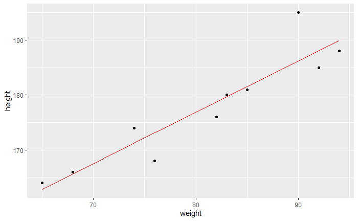

```r
sample %>%
  ggplot(aes(x = weight)) +
  geom_point(aes(y = height)) +
  geom_line(aes(y = pred), col = "red")
```

```r
weights_predict <- tibble(
  weight = 50:120
)

weights_predict %>%
  add_predictions(new_model)
```

| weight | pred |
| --- | --- |
| 50 | 148.8533 |
| 51 | 149.7868 |
| 52 | 150.7204 |
| 53 | 151.6539 |
| 54 | 152.5875 |
| 55 | 153.5210 |
| 56 | 154.4546 |
| 57 | 155.3881 |
| 58 | 156.3217 |
| 59 | 157.2552 |

[output cut: 61 more lines]

The regression coefficient $b_1$ (more specifically, $b_{\textrm{weight}}$ in our case) links the outcome and explanatory variables in the following way.

**A $1$ unit increase in explanatory variable value changes the outcome variable value by an amount equal to $b_1$**.

So, in our case, a $1$kg increase in `weight` changes the predicted `height` by $0.9336$cm